# Homelessness in Seattle

This is our report on homelessness in Seattle. We got our data from [here](https://data.world/sasha/count-us-in-report-homelessness-data/workspace/file?filename=Count+Us+In.xlsx). The data was collected by the Regional Homelessness Authority, a legislation approved by the Seattle City Council that oversees the funding, policy, and services for dealing with the homelessness issue throughout the county. They do a yearly count of the homeless population in King County. The data was generated partly by them, and partly by other organizations like the Puget Sound Regional Council and the Seattle King County Coalition on Homelessness. It’s a relational database, and it has 13 different tables, all focusing on different topics about homelessness.

## **Table**

Seattle Homeless Population Information on Race, Region, and Duration

[output not shown]

A question that we had in relation to Homelessness in King was relating to the demographics of the homeless population. We wanted to see what races made up what percentages of the homeless population. More specifically, what specific race had the biggest population of homelessness

## **Chart 1**

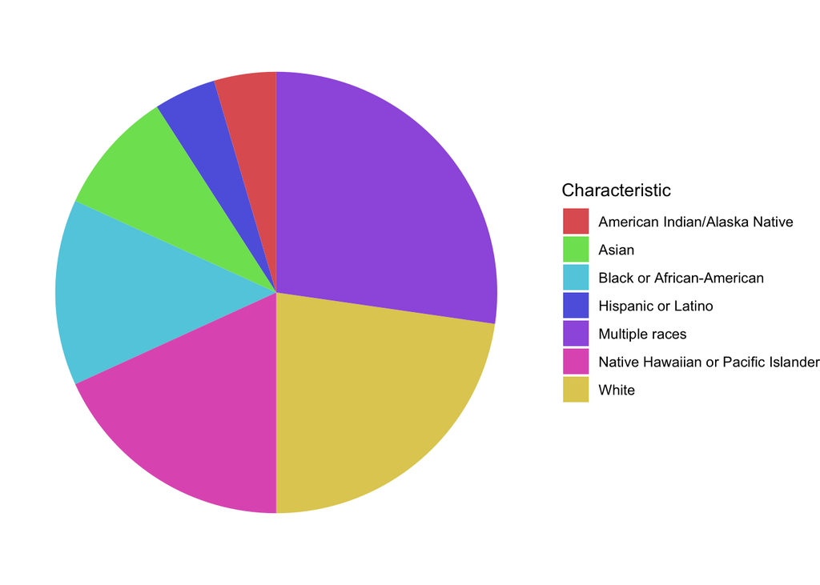

## **Chart 2**

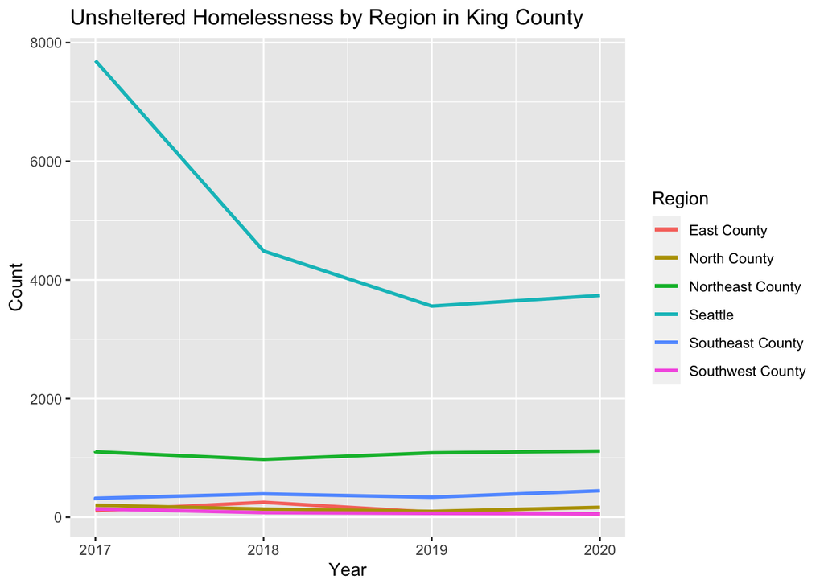

*Where does unsheltered homelessness occur the most in King County?*

This chart shows the unsheltered homeless count by region in King County from 2017-2020. This chart helps to see patterns of how many unsheltered homeless people there have been over the years and how it has changed in each region, as well as how that number of people compares to other regions. It is clear that over the last few years, Seattle is the region that has consistently had the most unsheltered homeless people. It can be seen in the chart that there is a much smaller gap between all of the other regions, with Seattle largely above all the other regions in count.

## **Chart 3**

[figure not shown]

[figure not shown]

[figure not shown]

[figure not shown]